# Design Detectives: DataLab

PS50008A Week 12 Lab

Gordon Wright

22 January 2026

# Welcome

## Your Data, Your Discoveries

## Lab Overview

Today we work through your **real DataLab results** as a class.

**Structure**

1. Task overview (me)
2. Small group discussion (you)
3. Whole-class debrief (together)
4. Repeat for each task

**Your Job**

- Form groups of 2-3
- Open the activity page
- Discuss the questions
- Be ready to share answers

## Timeline

| Phase | Task | Duration |
| --- | --- | --- |
| 1 | Reflex Test | 12 min |
| 2 | Time Warp | 10 min |
| 3 | Memory | 15 min |
| 4 | Frontal Lob | 12 min |
| 5 | Sleep & Memory | 12 min |
| 6 | Sixth Sense | 10 min |
| 7 | Wrap-up | 10 min |

**Total: ~80 minutes**

## Open the Activity Page

Navigate to **Week 12 > Lab > Activity**

You’ll see questions for each task.

Work through them with your group.

# Phase 1: Reflex Test

## How fast are your reactions?

## What You Did

You caught a falling **30cm ruler** five times.

The distance caught reflects **reaction time**:

$$\text{RT (ms)} = \sqrt{\frac{2 \times \text{distance (cm)}}{980}} \times 1000$$

**Shorter distance = faster reactions**

## Your Results

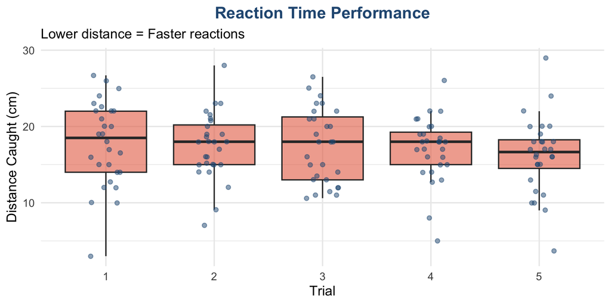

## Group Discussion

**In your groups, answer Questions 1.1-1.6:**

1. What pattern do you see from Trial 1 to Trial 5?
2. What design type is this? (Between/Within/Correlational)
3. What is the IV? What is the DV?
4. Write a hypothesis for the learning effect.

## Debrief: The Answers

**Design**: Within-subjects (same people, all trials)

**IV**: Trial number (1, 2, 3, 4, 5)

**DV**: Catch distance (cm) or reaction time (ms)

**Hypothesis (one-tailed)**: Reaction times will decrease from Trial 1 to Trial 5.

## The Learning Effect

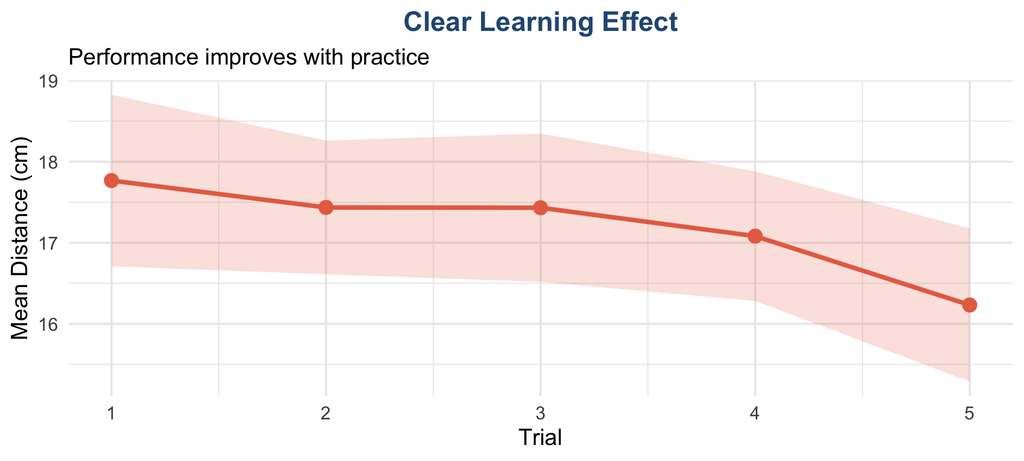

**Why does this matter?** Practice effects are a confound we control for in experiments.

# Phase 2: Time Warp

## How well do you perceive time?

## What You Did

You estimated **60 seconds** without counting.

Then you estimated the length of lines and strings.

## Your Time Estimates

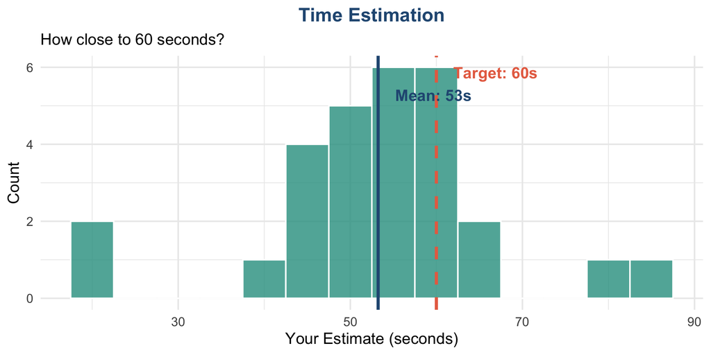

## Group Discussion

**In your groups, answer Questions 2.1-2.3:**

1. Did people over- or underestimate 60 seconds on average?
2. What design is this? (Between/Within/Correlational)
3. What would the null hypothesis be?

## Debrief: Time Perception

**Finding**: Most people **underestimate** 60 seconds (say it’s up before it actually is).

**Why?** When engaged in a task, time seems to pass faster.

**Design**: This is testing against a known value (60 seconds) - a one-sample design.

**Null hypothesis**: Mean estimate will equal 60 seconds (no systematic bias).

# Phase 3: Memory

## MindPalace

## What You Did

You memorised **10 words** and tried to recall them.

But here’s what you didn’t know…

## The Secret Manipulation

**Lab A** memorised:

ABSTRACT words

- Justice
- Freedom
- Wisdom
- Courage
- Truth

**Lab B** memorised:

CONCRETE words

- Chair
- River
- Mountain
- Apple
- Hammer

**Question**: Does word type affect memory?

## Your Results: Lab A vs Lab B

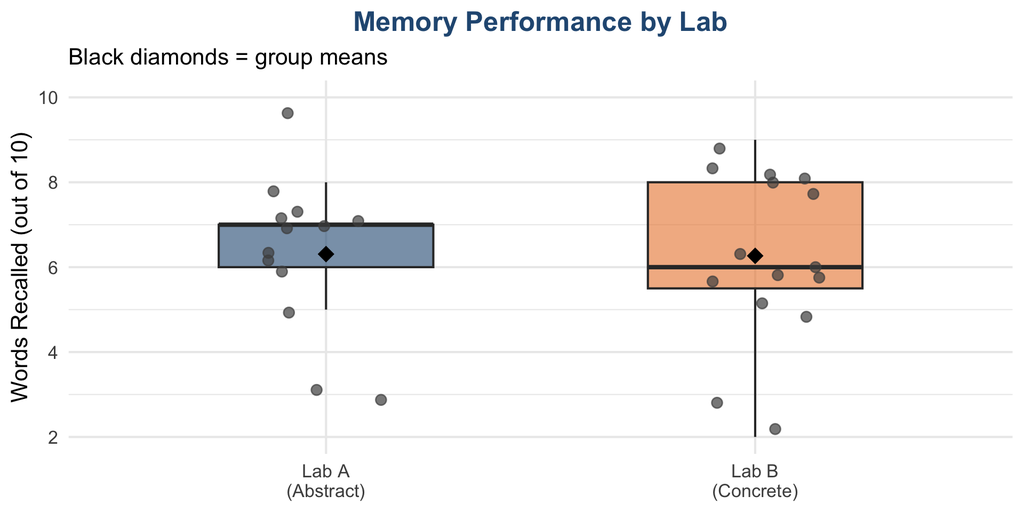

## The Statistics

| Lab | n | Mean | SD |
| --- | --- | --- | --- |
| Lab A |  |  |  |
| (Abstract) | 13 | 6.31 | 1.89 |
| Lab B |  |  |  |
| (Concrete) | 15 | 6.27 | 1.98 |

## Group Discussion

**In your groups, answer Questions 3.1-3.7:**

1. What is the IV? What is the DV?
2. What design type is this?
3. Write an experimental hypothesis (one-tailed).
4. Write a null hypothesis.
5. Why might concrete words be easier to remember?

## Debrief: Memory Design

**IV**: Word type (abstract vs concrete)

**DV**: Number of words recalled (0-10)

**Design**: Between-subjects (different people in each lab)

**Hypotheses**:

- **H1 (one-tailed)**: Concrete words will be recalled better than abstract words.
- **H0**: There will be no difference in recall between word types.

## Why Concrete Words?

**Dual Coding Theory** (Paivio, 1971)

Concrete words can be stored TWO ways:

1. **Verbal code** (the word itself)
2. **Visual code** (a mental image)

Abstract words only have the verbal code.

**Two codes > One code = Better memory**

# Phase 4: Frontal Lob

## Does handedness matter?

## What You Did

You threw balls at a bucket:

- **10 throws** with dominant hand
- **5 throws** with non-dominant hand

## Your Throwing Results

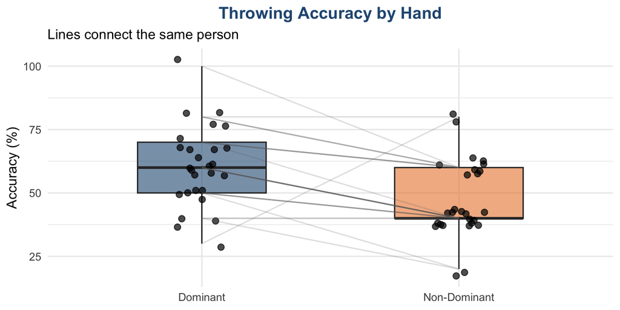

## Group Discussion

**In your groups, answer Questions 4.1-4.6:**

1. Same people or different people in each condition?
2. What design type is this?
3. Why is within-subjects “more powerful”?
4. What is the IV? What is the DV?

## Debrief: Within-Subjects Power

**Design**: Within-subjects (same person, both hands)

**IV**: Hand used (dominant vs non-dominant)

**DV**: Throwing accuracy (%)

**Why more powerful?**

Each person is their own control. Individual differences (height, coordination, practice) are controlled because we compare YOU to YOU.

# Phase 5: Sleep & Memory

## Is there a relationship?

## The Question

You told us how much sleep you got last night.

We measured how many words you recalled.

**Is there a relationship between sleep and memory?**

## Your Results

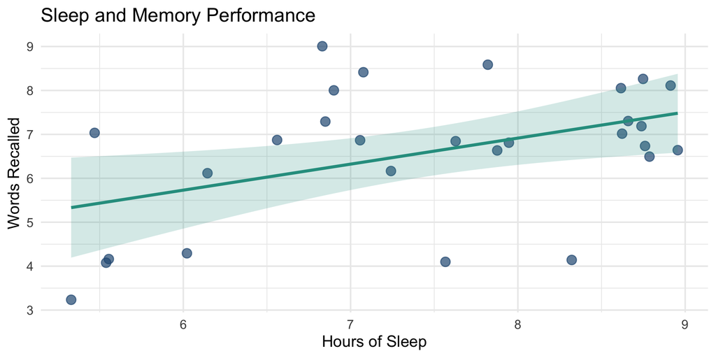

## Group Discussion

**In your groups, answer Questions 5.1-5.5:**

1. Is there an IV in this study?
2. What design type is this?
3. What does the correlation tell us?
4. Can we say sleep **causes** better memory?
5. What’s the key limitation of correlational designs?

## Debrief: Correlational Design

**Design**: Correlational (no manipulation)

**Variables**: Sleep hours AND memory score (neither is the IV)

**Key insight**: We measured BOTH variables — we didn’t manipulate either.

**The Critical Point**

**Correlation ≠ Causation**

Maybe sleep helps memory… OR maybe third variables (e.g., health, motivation) affect both!

# Phase 6: Sixth Sense

## Can you feel being stared at?

## What You Did

6 trials: Someone either stared at you or didn’t.

You guessed which it was.

**If just guessing**: You’d expect 50% correct (3 out of 6).

## Your Detection Accuracy

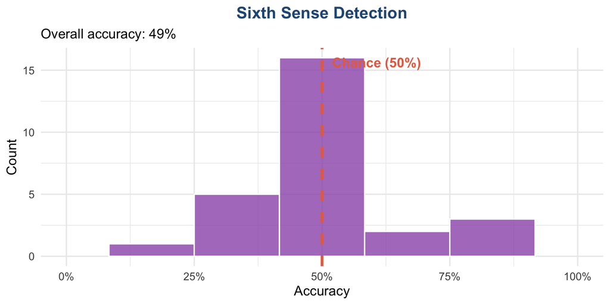

## Group Discussion

**In your groups, answer Questions 6.1-6.4:**

1. If someone got 5/6 correct, does that prove they have a sixth sense?
2. What is the null hypothesis here?
3. What would 50% accuracy suggest?

## Debrief: Chance and the Null Hypothesis

**H0**: Performance equals chance (50% - just guessing)

**H1**: Performance differs from chance

**Key insight**: Some people will get 5/6 or 6/6 just by luck, even with no real ability.

With 28 people flipping coins, SOMEONE will get 5+ heads. That doesn’t mean the coin is biased.

**This is why we need statistics** - to separate signal from noise.

# Wrap-Up

## What have we learned?

## Design Types Summary

| Design | Same people? | Example from today |
| --- | --- | --- |
| Between-subjects | No | Memory (Lab A vs Lab B) |
| Within-subjects | Yes | Throwing (Dom vs Non-dom) |
| Correlational | N/A | Sleep & Memory |

## Key Vocabulary

**Variables**

- **IV**: What’s manipulated
- **DV**: What’s measured

**Hypotheses**

- **H1**: Predicts an effect
- **H0**: Predicts no effect

**Direction**

- **One-tailed**: Predicts direction
- **Two-tailed**: Predicts difference only

**Key Concept**

- **Chance**: Random variation
- **Statistics**: Separating signal from noise

## Your Assessments

Everything today connects to your assessments:

| Assessment | What you practiced today |
| --- | --- |
| **Research Plan** | IV, DV, design types, hypotheses |
| **MCQ Exam** | All terminology and concepts |
| **EDS Assignment** | Means, SDs, interpreting results |

## Next Steps

1. Complete the **Week 12 Self-Assessment Quiz**
2. Review today’s activity page in your own time and look up terms in the glossary
3. Read about the **Research Plan** (due Week 16)